# Brecha de equipamiento digital y pobreza en Guatemala

Autor/a

Fernando Contreras Joshua Ascoli

# Introducción

Este proyecto analiza la tenencia de equipos digitales en los hogares de Guatemala según pobreza, área de residencia y departamento, utilizando datos derivados de la ENCOVI 2023.

Python se utiliza para leer, limpiar y validar los datos. R complementa el análisis estadístico y las visualizaciones. Quarto integra el código, los resultados y su interpretación en un documento reproducible.

# Datos y preguntas de investigación

## Preguntas

1. ¿Cómo varía la tenencia de equipos digitales según la pobreza?
2. ¿Qué diferencias existen entre áreas rurales y urbanas?
3. ¿Cómo se distribuye el equipamiento entre departamentos?
4. ¿Qué departamentos presentan perfiles similares de equipamiento?

## Origen y cobertura

Se utilizan dos archivos de equipamiento derivados de la ENCOVI 2023 del Instituto Nacional de Estadística de Guatemala, difundidos por OES DataLab / Guate en Datos.

El microdato contiene 548,200 registros: 10,964 hogares y 50 artículos por hogar. Cada fila representa un par hogar–artículo.

El resumen contiene 7,400 filas correspondientes a 148 combinaciones de departamento, área y pobreza, para 50 artículos. Incluye los 22 departamentos de Guatemala y las áreas rural y urbana.

El análisis se concentra en computadoras de escritorio, laptops, impresoras y tablets. Los archivos fuente se conservan sin modificar en la carpeta `datos/`.

## Variables principales

| Variable | Tipo | Descripción |
| --- | --- | --- |
| Departamento | Categórica | Departamento de residencia |
| Area | Categórica | Rural o urbana |
| Pobreza | Categórica | Clasificación de pobreza del hogar |
| Articulo | Categórica | Equipo o bien registrado |
| HogaresMuestra | Numérica | Hogares observados en el grupo |
| HogaresExpandido | Numérica | Total expandido de hogares del grupo |
| ConArticulo | Numérica | Hogares expandidos que poseen el artículo |
| ValorMedianoQ | Numérica | Valor mediano de venta reportado, en quetzales |
| AntiguedadMediaAnios | Numérica | Antigüedad media reportada, en años |

## Preparación y controles de calidad

- Se verificó la unicidad de las claves hogar–artículo en el microdato y grupo–artículo en el resumen.
- Se validaron denominadores positivos y conteos de hogares con artículo comprendidos entre cero y el total expandido del grupo.
- La categoría de pobreza `0` se identificó como `Sin clasificar`. Corresponde a 34 hogares de la muestra y se excluyó de las comparaciones socioeconómicas.
- Los valores ausentes asociados a no poseer un artículo se conservaron como nulos. No se sustituyeron por promedios.
- Se registró una inconsistencia: un hogar declaró no poseer una plancha eléctrica, pero informó una unidad. Se conservó el archivo original y esa cantidad no se incluyó en el conteo de unidades de poseedores.
- Se crearon `GrupoID`, `ArticuloClave` y `EsEquipoDigital` para identificar grupos, artículos y los cuatro equipos seleccionados.
- Los valores departamentales señalados como atípicos no se eliminaron únicamente por su posición en el gráfico de cajas.

## Cálculo de las tasas

Para un mismo artículo y conjunto de grupos:

$$\text{Tenencia (\%)} =
100 \times
\frac{\sum \text{ConArticulo}}
{\sum \text{HogaresExpandido}}$$

No se promedian porcentajes de grupos para estimar la tasa nacional. Tampoco se suman hogares poseedores de distintos equipos para calcular hogares con “algún equipo”, porque un hogar puede poseer varios.

## Limitaciones y consideraciones éticas

El microdato descargado carece de pobreza, territorio y factor de expansión. Por ello no se vincula artificialmente con esas variables; los cruces se calculan desde el resumen ponderado.

Los conteos expandidos publicados están redondeados. No se dispone del diseño muestral completo para estimar su incertidumbre.

Los resultados describen equipamiento en 2023. No miden internet, habilidades digitales ni rendimiento académico, y no demuestran causalidad. Se comunican resultados agregados y se evita estigmatizar a hogares o territorios.

Los archivos utilizados son derivados difundidos por OES DataLab, no la base original completa del INE. Guate en Datos permite el uso educativo y la redistribución de los datos citando las fuentes. Las URL de procedencia y las condiciones de uso se documentan en las referencias.

# Preparación de los datos con Python

El siguiente bloque ejecuta el procesamiento desde los archivos Excel incluidos en la carpeta `datos/`.

```r
python <- Sys.which("python3")
if (!nzchar(python)) python <- Sys.which("python")
if (!nzchar(python)) stop("No se encontró Python.")
reticulate::use_python(python, required = TRUE)
```

```python
import runpy
import sys
from pathlib import Path

raiz = Path.cwd()
if str(raiz) not in sys.path:
    sys.path.insert(0, str(raiz))

resultado = runpy.run_path(
    str(raiz / "analisis.py"),
    run_name="__main__"
)
```

Las filas del microdato representan pares hogar–artículo; no deben interpretarse como hogares independientes. Las comparaciones por pobreza y territorio utilizan el resumen ponderado, porque el microdato descargado no contiene esas variables.

# Análisis complementario con R

El siguiente bloque lee los CSV preparados por Python y calcula la tenencia de laptop por área a partir de los conteos expandidos.

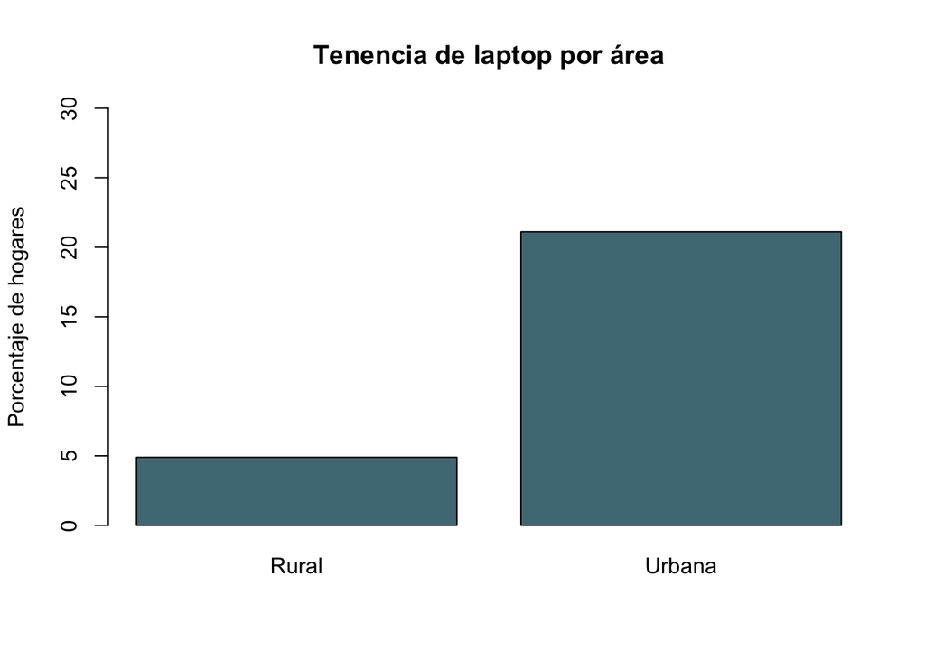

Tenencia de laptop en hogares rurales y urbanos.

```r
barplot(
  resumen_area$TenenciaPct,
  names.arg = resumen_area$Area,
  col = "#507984",
  main = "Tenencia de laptop por área",
  ylab = "Porcentaje de hogares",
  ylim = c(0, 30)
)
```

La tasa se calcula dividiendo los hogares expandidos que poseen laptop entre el total de hogares expandidos del área. Se excluyen los hogares sin clasificación de pobreza.

# Equipamiento digital según pobreza

Se comparan las tasas de tenencia de cuatro equipos entre hogares no pobres, pobres no extremos y pobres extremos.

```r
resultados_pobreza <- read.csv(
  "datos/resultados_pobreza.csv",
  fileEncoding = "UTF-8-BOM",
  stringsAsFactors = FALSE
)

knitr::kable(
  resultados_pobreza[c("Articulo", "Pobreza", "TenenciaPct")],
  digits = 2,
  caption = "Tenencia de equipos por condición de pobreza (%)."
)
```

Tenencia de equipos por condición de pobreza (%).

| Articulo | Pobreza | TenenciaPct |
| --- | --- | --- |
| Computadora de escritorio | No pobre | 11.10 |
| Computadora laptop | No pobre | 23.34 |
| Impresora | No pobre | 15.14 |
| Tablet | No pobre | 9.00 |
| Computadora de escritorio | Pobre extremo | 0.06 |
| Computadora laptop | Pobre extremo | 0.77 |
| Impresora | Pobre extremo | 0.10 |
| Tablet | Pobre extremo | 0.08 |
| Computadora de escritorio | Pobre no extremo | 2.52 |
| Computadora laptop | Pobre no extremo | 4.02 |
| Impresora | Pobre no extremo | 2.62 |
| Tablet | Pobre no extremo | 1.71 |

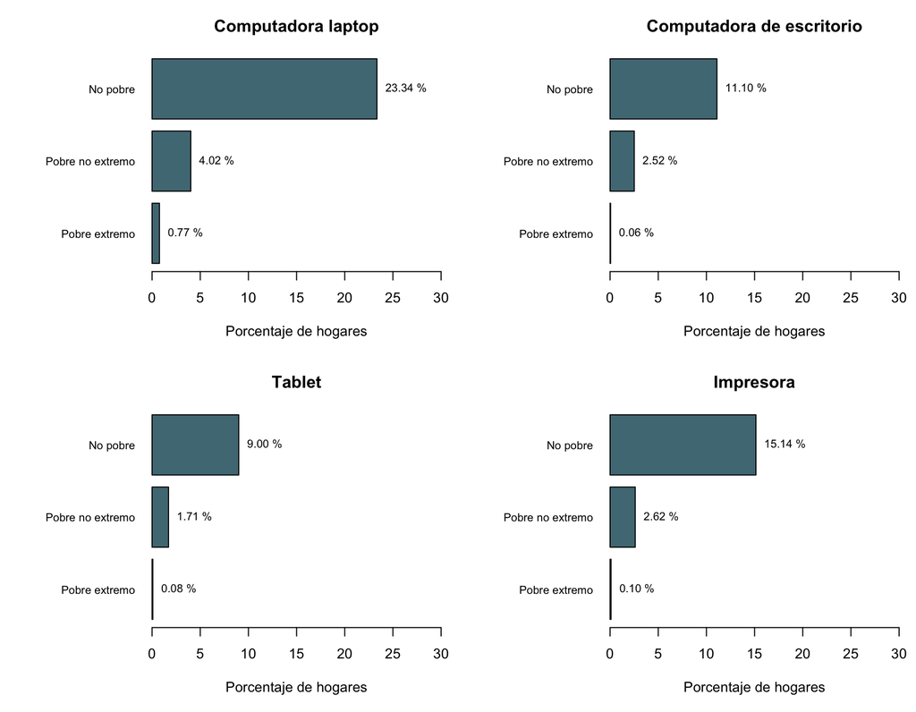

Porcentaje de hogares con cada equipo según pobreza.

```r
orden_pobreza <- c("No pobre", "Pobre no extremo", "Pobre extremo")
equipos <- c(
  "Computadora laptop",
  "Computadora de escritorio",
  "Tablet",
  "Impresora"
)

configuracion <- par(mfrow = c(2, 2), mar = c(5, 9, 3, 1))

for (equipo in equipos) {
  tabla <- subset(resultados_pobreza, Articulo == equipo)
  tabla <- tabla[match(orden_pobreza, tabla$Pobreza), ]

  posiciones <- barplot(
    rev(tabla$TenenciaPct),
    names.arg = rev(tabla$Pobreza),
    horiz = TRUE,
    las = 1,
    col = "#507984",
    xlim = c(0, 30),
    main = equipo,
    xlab = "Porcentaje de hogares",
    cex.names = 0.8
  )

  text(
    x = rev(tabla$TenenciaPct),
    y = posiciones,
    labels = sprintf("%.2f %%", rev(tabla$TenenciaPct)),
    pos = 4,
    cex = 0.8
  )
}
```

```r
par(configuracion)
```

## Hallazgo principal

```r
tasas_laptop <- subset(
  resultados_pobreza,
  Articulo == "Computadora laptop"
)

tasa_no_pobre <- tasas_laptop$TenenciaPct[
  tasas_laptop$Pobreza == "No pobre"
]

tasa_extrema <- tasas_laptop$TenenciaPct[
  tasas_laptop$Pobreza == "Pobre extremo"
]

brecha_laptop <- tasa_no_pobre - tasa_extrema
```

La tenencia de laptop alcanza el 23.34 % en hogares no pobres y el 0.77 % en hogares en pobreza extrema. La diferencia es de **22.57 puntos porcentuales**.

Esta diferencia describe una asociación entre pobreza y equipamiento. No permite establecer que la posesión de una laptop cause una reducción de la pobreza.

# Distribución del equipamiento entre departamentos

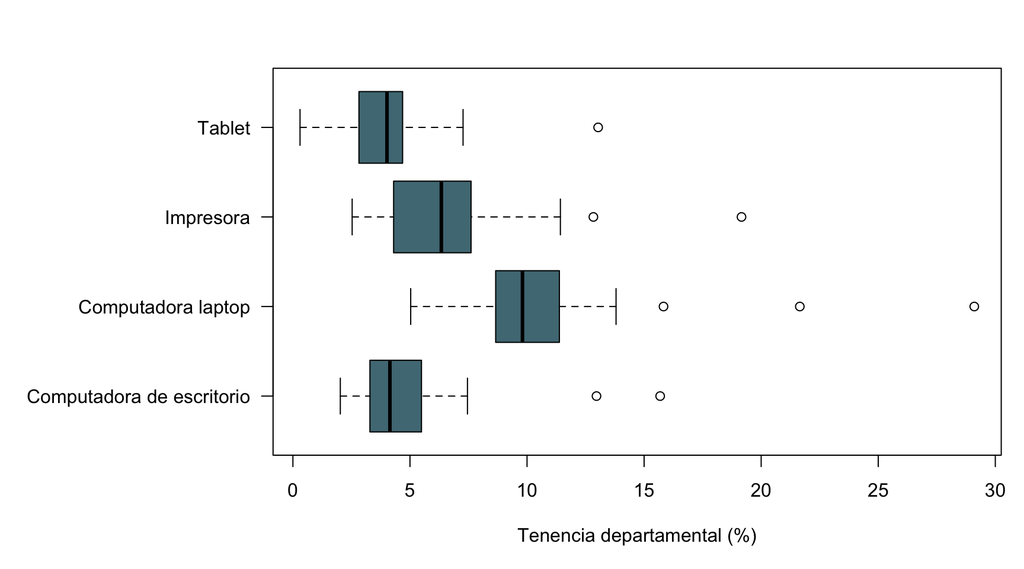

Distribución de las 22 tasas departamentales por equipo.

```r
op <- par(mar = c(5, 12, 3, 1))

boxplot(
  TenenciaPct ~ Articulo,
  data = tasas_departamento,
  horizontal = TRUE,
  las = 1,
  col = "#507984",
  xlab = "Tenencia departamental (%)",
  ylab = ""
)
```

```r
par(op)
```

```r
knitr::kable(
  estadisticas,
  digits = 2,
  caption = "Estadísticas de las tasas de tenencia en los 22 departamentos (%)."
)
```

Estadísticas de las tasas de tenencia en los 22 departamentos (%).

| Articulo | Departamentos | Minimo | Mediana | Media | Maximo | Desviacion |
| --- | --- | --- | --- | --- | --- | --- |
| Computadora de escritorio | 22 | 2.03 | 4.14 | 5.17 | 15.69 | 3.33 |
| Computadora laptop | 22 | 5.03 | 9.80 | 11.15 | 29.10 | 5.30 |
| Impresora | 22 | 2.53 | 6.34 | 7.05 | 19.16 | 3.78 |
| Tablet | 22 | 0.30 | 4.02 | 4.07 | 13.04 | 2.60 |

Estas estadísticas dan igual peso a cada departamento. Por tanto, la media departamental no equivale al porcentaje nacional de hogares que poseen el equipo.

Los valores señalados como atípicos en el gráfico de cajas se conservan: una tasa elevada no constituye por sí sola un error. Tampoco demuestra una diferencia estadísticamente significativa, porque este análisis no incorpora la incertidumbre del diseño muestral.

# Relaciones entre equipos

Se calculan correlaciones de Spearman entre las tasas departamentales de los cuatro equipos. Cada observación corresponde a un departamento.

```r
knitr::kable(
  correlaciones,
  digits = 3,
  caption = "Correlaciones de Spearman entre tasas departamentales."
)
```

Correlaciones de Spearman entre tasas departamentales.

|  | Computadora de escritorio | Computadora laptop | Impresora | Tablet |
| --- | --- | --- | --- | --- |
| Computadora de escritorio | 1.000 | 0.689 | 0.836 | 0.502 |
| Computadora laptop | 0.689 | 1.000 | 0.738 | 0.366 |
| Impresora | 0.836 | 0.738 | 1.000 | 0.535 |
| Tablet | 0.502 | 0.366 | 0.535 | 1.000 |

Las correlaciones describen asociaciones territoriales. No permiten concluir que los mismos hogares poseen ambos equipos ni establecer relaciones causales. Tampoco incorporan la incertidumbre de las estimaciones de la encuesta.

La mayor correlación territorial se observa entre computadoras de escritorio e impresoras (Spearman = 0.836), seguida de laptops e impresoras (0.738). Los departamentos con mayor tenencia de estos equipos tienden a ocupar posiciones similares en ambos indicadores. La asociación entre laptops y tablets es menor (0.366), lo que sugiere un orden territorial menos coincidente. Estos resultados corresponden a departamentos, no a la posesión conjunta de equipos en un mismo hogar.

# Segmentación territorial mediante clustering

## Método

Se aplicó clustering jerárquico a los 22 departamentos utilizando las tasas de tenencia de computadoras de escritorio, laptops, impresoras y tablets.

Las cuatro variables se estandarizaron para evitar que sus diferencias de escala dominaran el análisis. Se utilizó distancia euclidiana y el método Ward.D2. Cada departamento recibió igual peso.

Se compararon soluciones de dos a cinco grupos mediante la silueta promedio: valores mayores indican una mejor separación interna.

```r
knitr::kable(
  evaluacion_clusters,
  digits = 3,
  caption = "Comparación de las soluciones de clustering."
)
```

Comparación de las soluciones de clustering.

| Grupos | SiluetaPromedio |
| --- | --- |
| 2 | 0.698 |
| 3 | 0.283 |
| 4 | 0.258 |
| 5 | 0.232 |

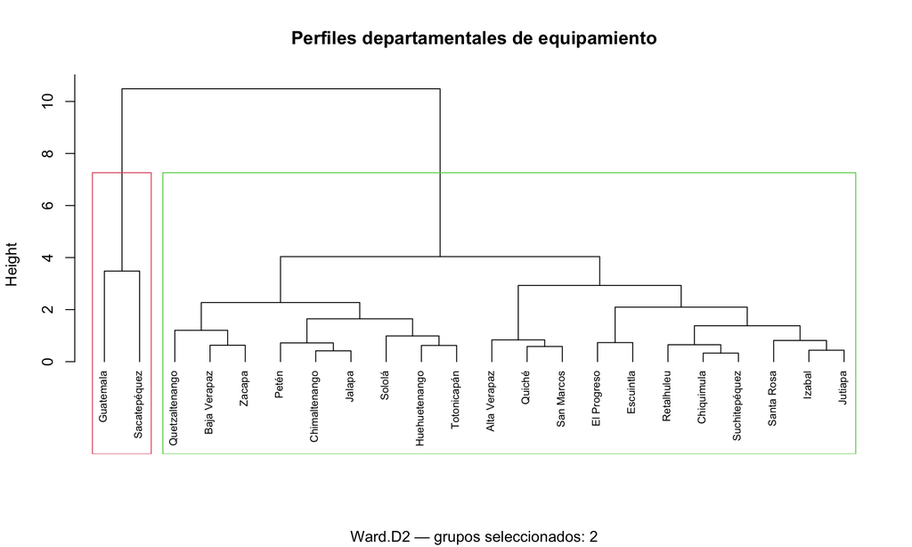

Agrupamiento jerárquico de departamentos según equipamiento.

```r
plot(
  modelo_jerarquico,
  main = "Perfiles departamentales de equipamiento",
  xlab = "",
  sub = paste("Ward.D2 — grupos seleccionados:", mejor_k),
  cex = 0.7,
  hang = -1
)

rect.hclust(modelo_jerarquico, k = mejor_k, border = 2:6)
```

## Resultados

Entre las opciones evaluadas, la solución de dos grupos obtuvo la mayor silueta promedio (0.698).

```r
knitr::kable(
  perfiles_clusters,
  digits = 2,
  caption = "Media de las tasas departamentales por grupo (%)."
)
```

Media de las tasas departamentales por grupo (%).

| Grupo | Computadora de escritorio | Computadora laptop | Impresora | Tablet |
| --- | --- | --- | --- | --- |
| 1 | 4.25 | 9.73 | 6.16 | 3.51 |
| 2 | 14.33 | 25.38 | 16.00 | 9.67 |

El grupo 2 reúne a Guatemala y Sacatepéquez y presenta mayores tasas promedio en los cuatro equipos. El grupo 1 contiene los otros 20 departamentos y presenta tasas promedio inferiores.

Estas medias dan igual peso a cada departamento; no representan porcentajes conjuntos de hogares de cada grupo.

```r
knitr::kable(
  segmentacion,
  row.names = FALSE,
  caption = "Departamentos que integran cada grupo."
)
```

Departamentos que integran cada grupo.

| Departamento | Grupo |
| --- | --- |
| Alta Verapaz | 1 |
| Baja Verapaz | 1 |
| Chimaltenango | 1 |
| Chiquimula | 1 |
| El Progreso | 1 |
| Escuintla | 1 |
| Huehuetenango | 1 |
| Izabal | 1 |
| Jalapa | 1 |
| Jutiapa | 1 |
| Petén | 1 |
| Quetzaltenango | 1 |
| Quiché | 1 |
| Retalhuleu | 1 |
| San Marcos | 1 |
| Santa Rosa | 1 |
| Sololá | 1 |
| Suchitepéquez | 1 |
| Totonicapán | 1 |
| Zacapa | 1 |
| Guatemala | 2 |
| Sacatepéquez | 2 |

## Interpretación y limitaciones

La segmentación identifica perfiles territoriales de equipamiento. Puede orientar un diagnóstico más detallado para programas de acceso a dispositivos, pero no basta para asignar recursos sin evaluar necesidades locales.

La división de 20 y 2 departamentos muestra que dos territorios se distinguen del resto. No implica que los 20 departamentos restantes sean homogéneos.

La silueta mide separación interna, no precisión predictiva ni estabilidad ante cambios en los datos. Los grupos dependen de las variables, la estandarización y el método utilizados. No incorporan la incertidumbre del diseño muestral ni representan categorías de pobreza.

# Dashboard interactivo

El dashboard de Power BI complementa el informe con tres páginas:

1. **Pobreza y tecnología:** compara cuatro equipos por pobreza y permite filtrar por departamento y área.
2. **Comparación territorial:** muestra la tenencia de laptop por departamento y área, con un selector de pobreza.
3. **Hallazgos y metodología:** resume resultados, preparación de datos, limitaciones y propuesta de ingeniería.

El archivo editable y su exportación PDF se encuentran en `powerbi/`. Las cifras del dashboard y del informe utilizan el mismo criterio: conteos expandidos para un artículo específico y exclusión de hogares sin clasificación de pobreza en las comparaciones.

# Discusión y propuesta de ingeniería

Las diferencias observadas muestran que la disponibilidad de equipos varía según pobreza y territorio. Esto plantea una condición relevante para diseñar sistemas educativos y servicios digitales: no se debe suponer que todos los usuarios disponen de computadora propia.

Se propone evaluar un programa de reacondicionamiento y préstamo de computadoras, acompañado de centros comunitarios con software libre y capacitación. Las aplicaciones podrían ofrecer materiales descargables y funciones sin conexión, cuya pertinencia deberá validarse con información adicional sobre conectividad.

La ubicación y los beneficiarios de un programa requieren un diagnóstico local. El clustering ofrece una descripción territorial, pero no constituye por sí solo una regla para asignar recursos.

Un piloto podría registrar:

- Equipos entregados, disponibilidad y fallas.
- Personas beneficiadas y frecuencia de uso.
- Costo por beneficiario.
- Participación y finalización de la capacitación.

Estos indicadores evaluarían la implementación. Atribuir mejoras educativas o económicas al programa requeriría un diseño de evaluación adicional.

# Conclusiones

1. En los datos de ENCOVI 2023, los hogares no pobres presentan mayores tasas de tenencia de los cuatro equipos analizados que los hogares en pobreza extrema.
2. La tenencia de laptop es aproximadamente 21.11 % en áreas urbanas y 4.89 % en áreas rurales, excluyendo hogares sin clasificación de pobreza.
3. Las tasas departamentales presentan diferencias importantes. La segmentación jerárquica distingue a Guatemala y Sacatepéquez del resto en la solución de dos grupos, sin implicar que los otros 20 departamentos sean homogéneos.
4. Las correlaciones describen asociaciones entre perfiles departamentales. No identifican posesión conjunta en hogares ni relaciones causales.
5. La integración de Python, R, Quarto y Power BI permite documentar la preparación, regenerar resultados y explorar los hallazgos. Las decisiones deben considerar las limitaciones de la fuente y la incertidumbre de las estimaciones.

# Referencias

- INE Guatemala. Información sobre pobreza y ENCOVI: https://www.ine.gob.gt/pobreza-menu/
- INE Guatemala. Guía para el uso de las bases de datos ENCOVI 2023: https://www.ine.gob.gt/wp-content/uploads/2024/11/Guia-para-el-uso-de-bases-de-datos_v_final.pdf
- OES DataLab / Guate en Datos. Portal de difusión: https://guateendatos.org.gt/oes-datalab/
- Archivo de equipamiento: https://guateendatos.org.gt/wp-content/uploads/encovi2023-equipamiento.xlsx?v=10226383
- Archivo de resumen: https://guateendatos.org.gt/wp-content/uploads/encovi2023-equipamiento-resumen.xlsx?v=367801

# Reproducibilidad

Los bloques de Python y R se ejecutan al renderizar este documento. Las rutas son relativas a la carpeta del proyecto.

```r
R.version.string
```

```
[1] "R version 4.6.2 (2026-10-29)"
```

```r
reticulate::py_config()
```

```
python:         /opt/homebrew/bin/python3
libpython:      /opt/homebrew/opt/python@3.14/Frameworks/Python.framework/Versions/3.14/lib/python3.14/config-3.14-darwin/libpython3.14.dylib
pythonhome:     /opt/homebrew/Cellar/python@3.14/3.14.0_1/Frameworks/Python.framework/Versions/3.14:/opt/homebrew/Cellar/python@3.14/3.14.0_1/Frameworks/Python.framework/Versions/3.14
version:        3.14.0 (main, Oct  7 2025, 09:34:52) [Clang 17.0.0 (clang-1700.3.19.1)]
numpy:           [NOT FOUND]

NOTE: Python version was forced by use_python() function
```